# R and related tools for research and teaching

4 December 2015

## Working more efficiently with R

[figure not shown]

## R

- More than 2 million users ([Oracle estimate](http://www.oracle.com/us/corporate/press/1515738) in 2012)
- 6th most popular programming language by [IEEE Spectrum](http://spectrum.ieee.org/computing/software/the-2015-top-ten-programming-languages) (in 2015)
- 3rd in number of scholarly articles in Google Scholar (in 2014; [blog post](http://r4stats.com/articles/popularity/) by R.A.Muenchen)
- UseR! 2015 conference: 660 participants, 284 from industry
- R activity around the world: http://rapporter.net/custom/R-activity
- https://www.r-project.org/

## Rstudio

- Open source graphical interface for R and related tools
- Code completion, syntax highlighting, code diagnostics
- Autosave, command history, plotting history, environment browser, integrated searchable help
- R projects for easy return to and switching between jobs
- https://www.rstudio.com/

## R Markdown

- Simple formatting syntax for authoring HTML and PDF documents and slides
- Based on Markdown language, `knitr`, and pandoc
- Fully reproducible documents
- Closely integrated to Rstudio (New File -> R Markdown)
- http://rmarkdown.rstudio.com/

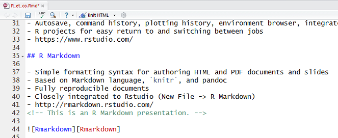

## Rmd features

- Equations like in LaTex: $y_i = \beta x_i$ produces \(y_i = \beta x_i\)
- Embedding R code in the document:

```r
summary(cars)
```

```
##      speed           dist
##  Min.   : 4.0   Min.   :  2.00
##  1st Qu.:12.0   1st Qu.: 26.00
##  Median :15.0   Median : 36.00
##  Mean   :15.4   Mean   : 42.98
##  3rd Qu.:19.0   3rd Qu.: 56.00
##  Max.   :25.0   Max.   :120.00
```

## Rmd figures

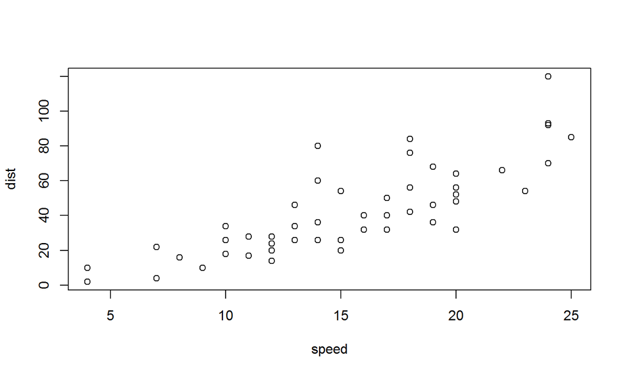

```r
plot(cars)
```

## Rmd tables

```
Type     | Freq  | %
---------| ------|-----
Apples   | 7     | 44
Oranges  | 9     | 56
```

| Type | Freq | % |
| --- | --- | --- |
| Apples | 7 | 44 |
| Oranges | 9 | 56 |

## R package creation

- Sharing work with others
  - Co-workers, CRAN etc.
- Personal projects
  - Loading functions, data and other packages at once
- Easier integration with C/C++/Fortran codes with R
- Getting started with `package.skeleton`
- In Rstudio: New Project -> New Directory -> R package

## Git

- Version control system originally for software development
- Useful for writing research articles, theses, R packages, …
- Basics are easy and sufficient for small projects
- Embedded in Rstudio (Tools -> Version Control)
- http://rogerdudler.github.io/git-guide/

## Github

- Web-based Git repository hosting service
- Interacting with other developers and users
- Bug tracking, feature requests, task management, …
- Free for public repositories
  - Free private repositories e.g. in [Bitbucket](https://bitbucket.org/)
- https://github.com/helske

## Useful packages for graphics

- `ggplot2`
  - Plotting system based on the grammar of graphics
  - Easy to produce complex multi-layered graphics
- `ggvis`
  - Similar to `ggplot2`, faster but more restricted
  - Interactive graphics in RStudio or a browser
- `grid`, `gridBase`
  - Control and flexibility in appearance and arrangement
  - Basis for developing high-level functions

## Useful packages for data manipulation

- `magrittr`
  - Piping via `%>%` operator
  - Improves readability and maintainability of code
- `dplyr` and `data.table`
  - Enhanced versions of `data.frame`
  - Fast and memory-efficient
  - More flexible data manipulation
  - Working with remote databases, automatic translation to SQL (`dplyr`)

## Useful packages for reporting

- `knitr`
  - Dynamic report generation (PDF, html, Word, …)
  - Easy to re-compile and update outputs
- `shiny`
  - Building interactive web applications from R
  - Web development skills not required

## Useful packages for packaging

- `testthat`
  - Testing framework for R
  - Catching errors, warnings, messages, …
- `devtools`
  - Simplifying tasks in package development
- `roxygen2`
  - Writing documentation for functions etc.
- `Rcpp`
  - Simple C++ integration in R
  - Writing C++ separately, Rcpp handles the ugly stuff

## Learning

- Read
  - [RStudio Online learning](https://www.rstudio.com/resources/training/online-learning/)
  - [Quick-R](http://www.statmethods.net/)
  - [OpenIntro](https://www.openintro.org/)
- Hands-on learning online
  - [DataCamp](https://www.datacamp.com/)
    - R tutorials and data science courses in browser
  - [Codeschool](https://www.codeschool.com/)
    - Learn R, Git, SQL, …
- Hands-on in R
  - [`swirl` package](http://swirlstats.com/)

## Teaching I

- [OpenIntro](https://www.openintro.org/)
  - Free material for teachers to use and modify
  - Textbooks, slides, excercises, …
  - Statistics, R, SAS, …
- [DataCamp](https://www.datacamp.com/)
  - Resources for building own courses
- [`testwhat` package](https://github.com/Data-Camp/testwhat)
  - Wrapper around `testthat` for checking exercises

## Teaching II

- [Shiny apps](http://statistics.calpoly.edu/shiny) by Cal Poly State University
  - Correlation and regression game, sampling distribution demonstration, longest run of heads or tails, …
- [Using Github](https://github.com/rundel/Presentations/blob/master/UseR2015/user2015.pdf) (experiences by Colin Rundel)
  - Assignments turned in via Github
  - Students learn version control
  - Simpler course administration
  - Keeping track of contributions

## Getting help

- [Stack overflow](http://stackoverflow.com/)
- [Google](http://google.com/)…